# Example 1 Simple Sphere.

In this example, we illustrate the use of MPT Calculator for a simple sphere of radius 1, scaled by $\alpha = 0.01$ m, with conductivity $\sigma_* = 10^6$ S/m, and $\mu_r = 1$ over the frequency range $10^1 \ge \omega \ge 10^8$ rad/s using the full order solver and a single processor using an order 3 approximation and a coarse discretisation.

## Defining material properties

The object in question is defined in OCC_sphere.py following the format defined in Tutorial 5. To update the conductivity or permeability, change lines 13 and 14 to the appropriate values.

Recall that the OCC geometries must be saved in the $\texttt{/OCC\_Geometry/}$ folder and that the mesh saved on line 44 must match the file name of the python file. In this example that is $\texttt{VolFiles/OCC\_sphere.vol}$.

## Defining object size and frequency sweep

Here, we specify that we want to consider a sphere with $\alpha=0.01$ m and the frequency range $10^1 \ge \omega \ge 10^8$. In this example, we wish to consider 20 logarithmically spaced frequencies.

```python
geometry = 'OCC_sphere.py'
alpha = 0.01
start_stop = (1,8,20)
order = 3
mesh_coarseness = 'coarse'
```

## Running the simulation

Finally, we run the simulation with our prescribed settings. Note that we first have to specify the root directory.

```python
import os
# Please edit this line to provide the to the root directory of your copy of MPT-Calculator
Your_Path = r"/home/pdl11/Coding/MPT_calculator/Sept2025/MPT-Calculator"#'C:\Users\James\Desktop\MPT-Calculator'
os.chdir(Your_Path)
os.getcwd()
```

```
'/home/pdl11/Coding/MPT_calculator/Sept2025/MPT-Calculator'
```

```
Updated alpha from OCC file. Alpha=0.01
OCC_sphere.geo
[0, 1] 2 ['air', 'steel']
Mesh Contains Prisms? False
N Prisms: 0, N Tets: 18237
[0, 1] 2 ['air', 'steel']
```

```
 Running as full sweep
 mesh contains 18237 elements
Running Bilinear Forms Check
Mesh curve order set to:  5
K: Iteration 1: bonus_intord = 2
K: Iteration 2: bonus_intord = 4
K: Iteration 3: bonus_intord = 6
K Bilinear Form Converged using order 8
C: Iteration 1: bonus_intord = 2
C: Iteration 2: bonus_intord = 4
C Bilinear Form Converged using order 6
```

```
 solved theta0 problems
 solved theta0 problems
```

```
 solved theta1 problems
 frequency sweep complete
```

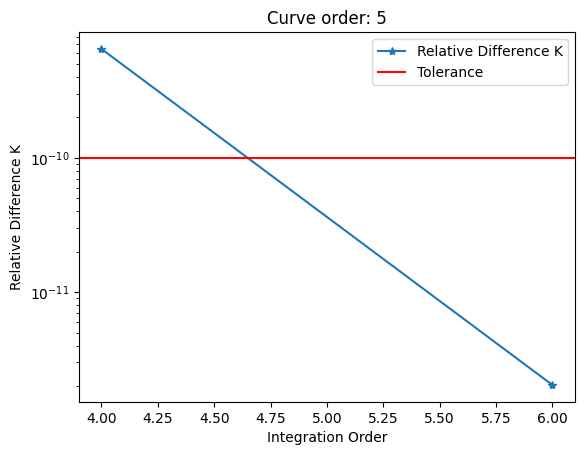

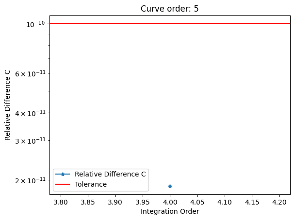

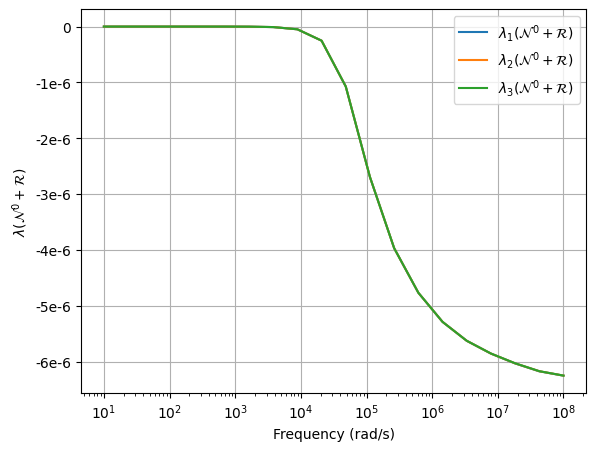

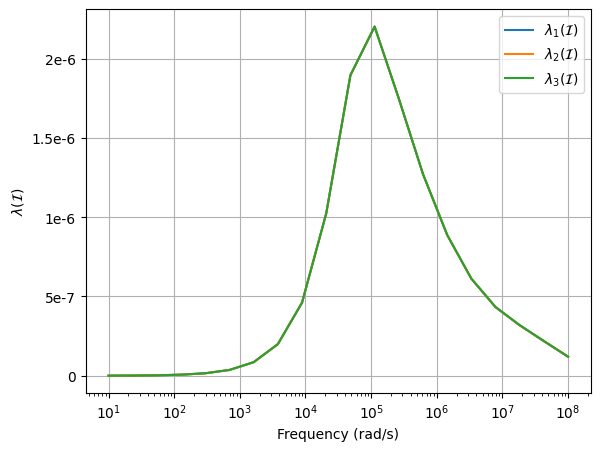

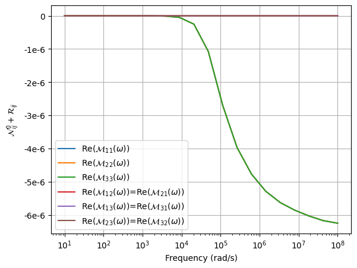

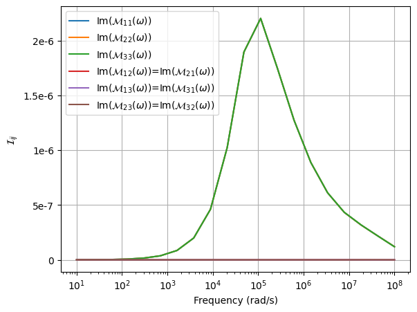

```python
from main import main
results = main(geometry=geometry, order=order, alpha=alpha, h=mesh_coarseness, start_stop=start_stop, use_OCC=True, use_parallel=False)
```